# tidycensus_tinkering

Colleen Minnihan

4/14/2021

#load packages

```r
library(tidycensus)
library(tidyverse)
library(sf)
```

#get API Key: http://api.census.gov/data/key_signup.html.

Make sure you don’t push with your key in plain sight!

```r
#census_api_key("key")
```

```r
#in geography you can put us, region, state, county, school district (elementary, secondary, unified)

#to see variables
#View(load_variables(year = 2019, "acs5", cache = TRUE))
```

```r
#median income in last 12 months by county
get_acs(geography = "county",
        variables = "B06011_001",
        state = "MN",
        year = 2019)
```

```
## # A tibble: 87 x 5
##    GEOID NAME                         variable   estimate   moe
##    <chr> <chr>                        <chr>         <dbl> <dbl>
##  1 27001 Aitkin County, Minnesota     B06011_001    26586   763
##  2 27003 Anoka County, Minnesota      B06011_001    39688   561
##  3 27005 Becker County, Minnesota     B06011_001    31304   637
##  4 27007 Beltrami County, Minnesota   B06011_001    25619   893
##  5 27009 Benton County, Minnesota     B06011_001    32419  1546
##  6 27011 Big Stone County, Minnesota  B06011_001    28857  2968
##  7 27013 Blue Earth County, Minnesota B06011_001    27486   973
##  8 27015 Brown County, Minnesota      B06011_001    32186   863
##  9 27017 Carlton County, Minnesota    B06011_001    31007  1394
## 10 27019 Carver County, Minnesota     B06011_001    45984   947
## # … with 77 more rows
```

```r
#median income in last 12 months by school district (unified: K-12)
get_acs(geography = "school district (unified)",
        variables = "B06011_001",
        state = "MN",
        year = 2019)
```

```
## # A tibble: 324 x 5
##    GEOID   NAME                                         variable  estimate   moe
##    <chr>   <chr>                                        <chr>        <dbl> <dbl>
##  1 2700001 Mountain Iron-Buhl School District, Minneso… B06011_0…    28003  3529
##  2 2700005 United South Central School District, Minne… B06011_0…    29864  2100
##  3 2700006 Maple River School District, Minnesota       B06011_0…    34198  1977
##  4 2700007 Kingsland Public School District, Minnesota  B06011_0…    32222  2190
##  5 2700008 St. Louis County School District, Minnesota  B06011_0…    31287   854
##  6 2700013 Waterville-Elysian-Morristown Public School… B06011_0…    34332  1553
##  7 2700017 Chisago Lakes School District, Minnesota     B06011_0…    41616  1454
##  8 2700019 Minnewaska School District, Minnesota        B06011_0…    33996  1522
##  9 2700021 Eveleth-Gilbert School District, Minnesota   B06011_0…    31012  1679
## 10 2700022 Wadena-Deer Creek School District, Minnesota B06011_0…    26414  2349
## # … with 314 more rows
```

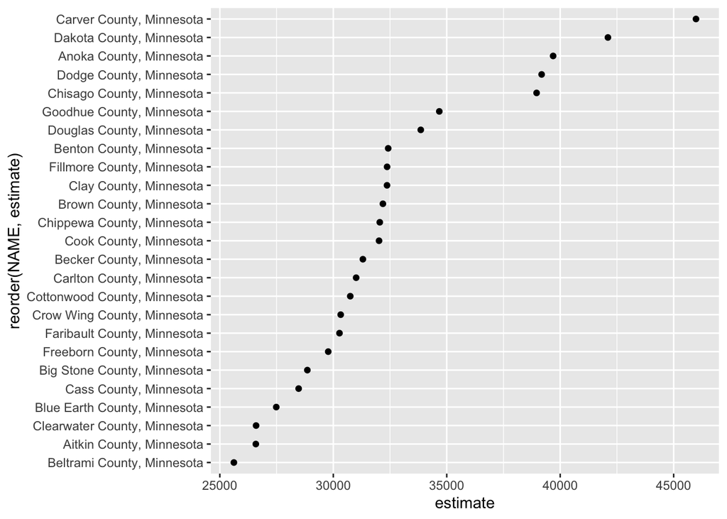

```r
#visualizing median income in last 12 months by county
income_county <- get_acs(geography = "county",
        variables = "B06011_001",
        state = "MN",
        year = 2019)
income_county[1:25,] %>%
  ggplot(aes(x = estimate, y = reorder(NAME, estimate))) +
  geom_point()
```

```r
#"Black or African American alone" race by school district
get_acs(geography = "school district (unified)",
        variables = "B02001_003",
        state = "MN",
        year = 2019)
```

```
## # A tibble: 324 x 5
##    GEOID   NAME                                         variable  estimate   moe
##    <chr>   <chr>                                        <chr>        <dbl> <dbl>
##  1 2700001 Mountain Iron-Buhl School District, Minneso… B02001_0…       63    55
##  2 2700005 United South Central School District, Minne… B02001_0…       10    18
##  3 2700006 Maple River School District, Minnesota       B02001_0…       26    36
##  4 2700007 Kingsland Public School District, Minnesota  B02001_0…        7     8
##  5 2700008 St. Louis County School District, Minnesota  B02001_0…       71    44
##  6 2700013 Waterville-Elysian-Morristown Public School… B02001_0…       21    26
##  7 2700017 Chisago Lakes School District, Minnesota     B02001_0…       40    31
##  8 2700019 Minnewaska School District, Minnesota        B02001_0…       32    26
##  9 2700021 Eveleth-Gilbert School District, Minnesota   B02001_0…       30    29
## 10 2700022 Wadena-Deer Creek School District, Minnesota B02001_0…       68    60
## # … with 314 more rows
```

```r
#"White alone" race by school district
get_acs(geography = "school district (unified)",
        variables = "B02001_002",
        state = "MN",
        year = 2019)
```

```
## # A tibble: 324 x 5
##    GEOID   NAME                                         variable  estimate   moe
##    <chr>   <chr>                                        <chr>        <dbl> <dbl>
##  1 2700001 Mountain Iron-Buhl School District, Minneso… B02001_0…     4251   198
##  2 2700005 United South Central School District, Minne… B02001_0…     5517   155
##  3 2700006 Maple River School District, Minnesota       B02001_0…     5802   225
##  4 2700007 Kingsland Public School District, Minnesota  B02001_0…     4773   209
##  5 2700008 St. Louis County School District, Minnesota  B02001_0…    15739   380
##  6 2700013 Waterville-Elysian-Morristown Public School… B02001_0…     6560   297
##  7 2700017 Chisago Lakes School District, Minnesota     B02001_0…    20774   403
##  8 2700019 Minnewaska School District, Minnesota        B02001_0…     9195   132
##  9 2700021 Eveleth-Gilbert School District, Minnesota   B02001_0…     8626   243
## 10 2700022 Wadena-Deer Creek School District, Minnesota B02001_0…     7532   267
## # … with 314 more rows
```

```r
#maybe we should convert these to percentages rather than a number (when we do data wrangling)
```

Visualize school districts in MN by median income

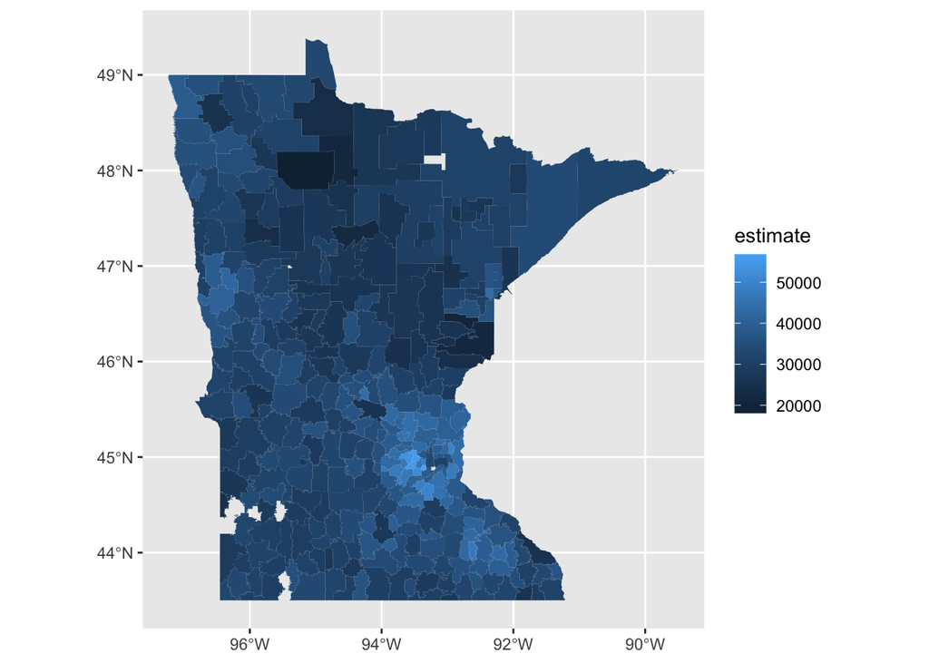

```r
district_income <- get_acs(state = "MN", geography = "school district (unified)",
                  variables = "B06011_001", geometry = TRUE, year = 2019)
district_income %>%
  ggplot(aes(fill = estimate)) +
  geom_sf(color = NA)
```

Visualize counties in MN by median income

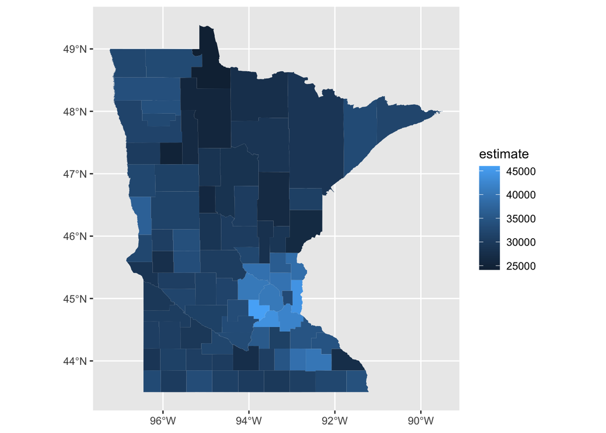

```r
county_income <- get_acs(state = "MN", geography = "county",
                  variables = "B06011_001", geometry = TRUE, year = 2019)
county_income %>%
  ggplot(aes(fill = estimate)) +
  geom_sf(color = NA)
```

Potential variables to look at for the 2019 census:

**POPULATION** *total population (B01003_001) (perhaps the bigger districts are more likely to offer it)

**SEX** * Male 5-9 years old (B01001_004) * Male 10-14 years old (B01001_005) * Male 15-17 years old (B01001_006) (I would imagine that schools with a larger number of men may be more likely to have comp sci offerings?)

**RACE** * Race: white alone (B02001_002) * Race: Black or African American alone (B02001_003) * Race: Asian alone (B02001_005) * Race: Native Hawaiian and other pacific islander alone (B02001_006) * Race: Two or more races (B02001_008)

**INCOME/POVERTY** * Median household income in last 12 months (B19013_001) * receive supplemental security income, cash public assistance income, or food stamps in households w/ child under 18 (B09010_001) * number of earners in family (B19122_001) * median gross rent (B25031_001) * housing units w/ a mortgage (B25027_001)

**HOME ENVIRONMENT** * Prescence of computer and internet subscription in household (B28003_001)

#load ACT data

```r
act <- read_csv("act_data.csv")
#data cleaning
act_clean <-
act %>%
  filter(`Grad Year` == 2018,
         `Analysis Level` == "District",
         `District Name` != "MINNESOTA DEPT OF EDUCATION",
         `Avg Comp` != ".") %>%
  select(`District Name`, `Avg Comp`) %>%
  mutate(`Dist Num` = as.integer(str_extract_all(`District Name`, "[:digit:]+"))) %>%
  mutate(`Dist Num`= replace(`Dist Num`, `District Name`=="GRANADA-HUNTLEY-EAST CHAIN SD", 2536),
         `Dist Num`= replace(`Dist Num`, `District Name`=="ALBERT LEA AREA SCHOOLS", 241),
         `Dist Num`= replace(`Dist Num`, `District Name`=="ATWATER-COSMOS-GROVE CITY SD", 2396),
         `Dist Num`= replace(`Dist Num`, `District Name`=="BOLD SCHOOL DISTRICT", 2534),
         `Dist Num`= replace(`Dist Num`, `District Name`=="BUFFALO HANOVER MONTROSE SD", 0877),
         `Dist Num`= replace(`Dist Num`, `District Name`=="BUFFALO LAKE-HECTOR-STEWART SD", 2159),
         `Dist Num`= replace(`Dist Num`, `District Name`=="EASTERN CARVER CO SCHOOLS", 112),
         `Dist Num`= replace(`Dist Num`, `District Name`=="MANKATO AREA PUBLIC SCHS", 77),
         `Dist Num`= replace(`Dist Num`, `District Name`=="MINNEAPOLIS PUBLIC SCH DIST", 9991),
         `Dist Num`= replace(`Dist Num`, `District Name`=="MINNEOTA PUBLIC SCHOOLS", 414),
         `Dist Num`= replace(`Dist Num`, `District Name`=="PLAINVIEW ELGIN MILLVILLE SD", 2899),
         `Dist Num`= replace(`Dist Num`, `District Name`=="ROYALTON PUBLIC SCHOOLS", 485),
         `Dist Num`= replace(`Dist Num`, `District Name`=="WASECA PUBLIC SCHOOL DIST", 829),
         `Dist Num`= replace(`Dist Num`, `District Name`=="WAUBUN-OGEMA-WHITE EARTH PSD", 435),
         `Dist Num`= replace(`Dist Num`, `District Name`=="WINONA AREA PUBLIC SCHOOL DIST", 861))

act_clean
```

```
## # A tibble: 313 x 3
##    `District Name`                `Avg Comp` `Dist Num`
##    <chr>                          <chr>           <dbl>
##  1 KELLIHER SCHOOL DIST 36        21.5               36
##  2 NORMAN CO WEST ISD 2527        19.2             2527
##  3 BUTTERFIELD-ODIN IND SD 836    20.6              836
##  4 GRANADA-HUNTLEY-EAST CHAIN SD  18.8             2536
##  5 CAMPBELL-TINTAH IND SD 852     15.8              852
##  6 GLENVILLE-EMMONS ISD 2886      16.9             2886
##  7 LYLE IND SCHOOL DISTRICT 497   21.5              497
##  8 CLIMAX-SHELLY IND SCH DIST 592 17.2              592
##  9 HANCOCK IND SCH DIST 768       23                768
## 10 ASHBY IND SCHOOL DISTRICT 261  19.2              261
## # … with 303 more rows
```

#Making a dataset with relevant census variables

```r
mn_2019_census <- get_acs(state = "MN",
                         geography = "school district (unified)",
                         variables = c("B01003_001",
                                       "B01001_004",
                                       "B01001_005",
                                       "B01001_006",
                                       "B02001_002",
                                       "B02001_003",
                                       "B02001_005",
                                       "B02001_006",
                                       "B02001_008",
                                       "B19013_001",
                                       "B09010_001",
                                       "B25031_001",
                                       "B25027_001",
                                       "B28003_001"),
                         geometry = TRUE,
                         year = 2019)
mn_2019_census_nogeom <- mn_2019_census %>%
  st_drop_geometry() %>% #get rid of the geometry so we can spread()
  select(-`moe`) %>% #get rid of moe variable(not sure what it is)
  spread(variable, estimate) %>% #give each variable a column
  rename(total_pop = B01003_001,
         male_5to9 = B01001_004,
         male_10to14 = B01001_005,
         male_15to17 = B01001_006,
         race_white_only = B02001_002,
         race_Black_only = B02001_003,
         race_Asian_only = B02001_005,
         race_pacific_islander_only = B02001_006,
         at_least_two_races = B02001_008,
         med_household_inc_12mo = B19013_001,
         SSI_pubassist_foodstamps = B09010_001,
         med_gross_rent = B25031_001,
         house_units_w_mortgage = B25027_001,
         comp_internet_subscrip_in_house = B28003_001
         ) %>% #rename variables
  mutate(District = str_extract(`NAME`, "[^,]+")) %>% #delete ", Minnesota" after district name
  select(-NAME)#remove `NAME` column


mn_2019_census_nogeom
```

```
##       GEOID male_5to9 male_10to14 male_15to17 total_pop race_white_only
## 1   2700001       146         104          91      4545            4251
## 2   2700005       220         160         126      5790            5517
## 3   2700006       207         180         133      5991            5802
## 4   2700007       133         176          91      5023            4773
## 5   2700008       370         493         239     17435           15739
## 6   2700013       176         201          93      6707            6560
## 7   2700017       625         991         530     21544           20774
## 8   2700019       344         272         179      9502            9195
## 9   2700021       241         252         132      8811            8626
## 10  2700022       266         237         144      7953            7532
## 11  2700023       110         114          85      3706            3443
## 12  2700024       124         173          38      3732            3530
## 13  2700088        92         119          60      2812            2652
## 14  2700089       132         187         130      5006            4853
```

[output cut: 1610 more lines]

#load dataset with district numbers

```r
districts <- read_csv("districts.csv")
districts <- districts %>%
  mutate(District = `District Name`) %>%
  select(-`X3`, - `District Name`)
```

#join so that census dataset has district numbers

```r
mn_2019_census_nogeom <- mn_2019_census_nogeom %>%
  left_join(districts)
mn_2019_census_nogeom
```

```
##       GEOID male_5to9 male_10to14 male_15to17 total_pop race_white_only
## 1   2700001       146         104          91      4545            4251
## 2   2700005       220         160         126      5790            5517
## 3   2700006       207         180         133      5991            5802
## 4   2700007       133         176          91      5023            4773
## 5   2700008       370         493         239     17435           15739
## 6   2700013       176         201          93      6707            6560
## 7   2700017       625         991         530     21544           20774
## 8   2700019       344         272         179      9502            9195
## 9   2700021       241         252         132      8811            8626
## 10  2700022       266         237         144      7953            7532
## 11  2700023       110         114          85      3706            3443
## 12  2700024       124         173          38      3732            3530
## 13  2700088        92         119          60      2812            2652
## 14  2700089       132         187         130      5006            4853
```

[output cut: 1610 more lines]

```r
#the only NA value is for the "remainder of Minnesota"- should we get rid of this row anyways because it's not a school district?
colSums(is.na(mn_2019_census_nogeom))
```

```
##                           GEOID                       male_5to9
##                               0                               0
##                     male_10to14                     male_15to17
##                               0                               0
##                       total_pop                 race_white_only
##                               0                               0
##                 race_Black_only                 race_Asian_only
##                               0                               0
##      race_pacific_islander_only              at_least_two_races
##                               0                               0
##        SSI_pubassist_foodstamps          med_household_inc_12mo
##                               0                               0
##          house_units_w_mortgage                  med_gross_rent
##                               0                               0
## comp_internet_subscrip_in_house                        District
##                               0                               0
##                    District Nbr
##                               1
```